# Project 2

Angela Zhao

# **Introduction**

The kdrama.csv dataset shows the top 250 Korean dramas based on ratings from MyDramaList as of January 2023. The original source of the data is a site called [MyDramaList](https://mydramalist.com/shows/top), where users can rate and write reviews on shows, and additional information was collected from Wikipedia. The data was collected into a csv file by [Kaggle](https://www.kaggle.com/datasets/ahbab911/top-250-korean-dramas-kdrama-dataset).  
I chose to analyze this dataset because I watch a lot of kdramas, so I thought it would be interesting to see the trends among them.  
The variables I will be investigating are network, day aired on, rating, duration, and number of episodes.

[figure not shown]

Source: “The Family Is Coming: Korea: Drama: Watch with English Subtitles & More ✔️.” Rakuten Viki, 3 Jan. 2015, www.viki.com/tv/40242c-the-family-is-coming.

# **Data Preparation**

I downloaded a csv file from Kaggle that had the data gathered and sorted into a table. I read in the csv file into R. The dataset I got was mostly cleaned and organized. I took the duration, which was given in hours and minutes, and I converted it into minutes in a new variable by extracting the hour and minute numbers as a vector and multiplying the hour by 60 and adding it onto minutes to get total time in minutes. I also cleaned the variable for day(s) aired. There were some values that only appeared a couple of times, so I decided to change them into “Other” in the dataset. I had trouble figuring out how to change some values to “Other” if there were not enough observations in the dataset. I had to experiment with various code to figure out which ones would access the information I needed. There are some NA values, but they are not relevant to the variables I will be investigating, so I left them in the data. There are a total of 250 observations.

# **Variable Descriptions**

| Rating | Network | Duration | Aired | NumEpisodes |
| --- | --- | --- | --- | --- |
| Number | String | Number | String | Number |
| Ratings from users on MyDramaList | Platform where show was first released | Length of each episode(mins) | Day(s) of the week the show ran when aired | Number of episodes in the show |

# **Univariate Analyses**

### Rating

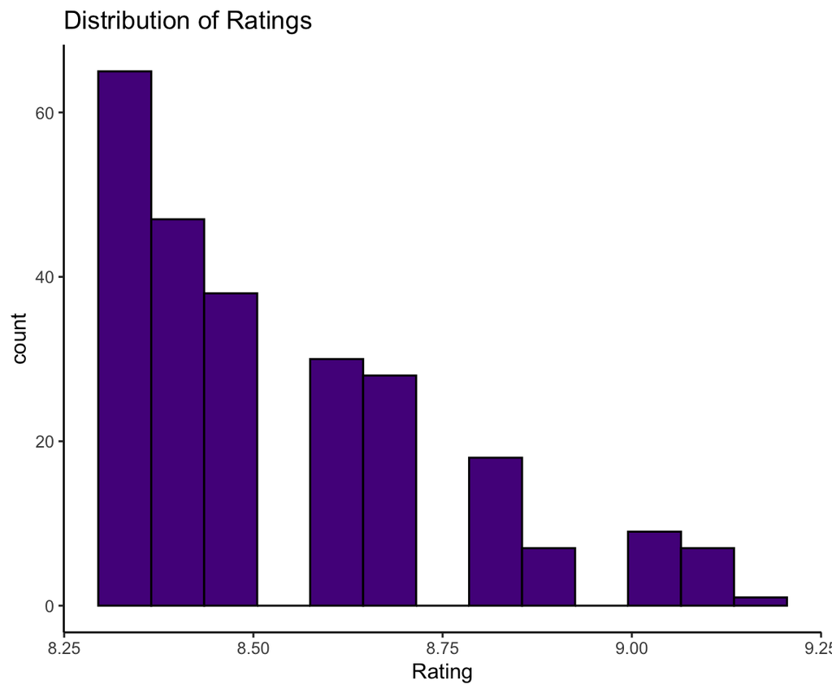

The distribution of the ratings of the top 250 kdramas has a mean of 8.5, with the highest rating of 9.2, lowest rating of 8.3. The graph shows that there are more kdramas with lower ratings than higher ratings. As the rating decreases, there are more kdramas with that rating.

### Network

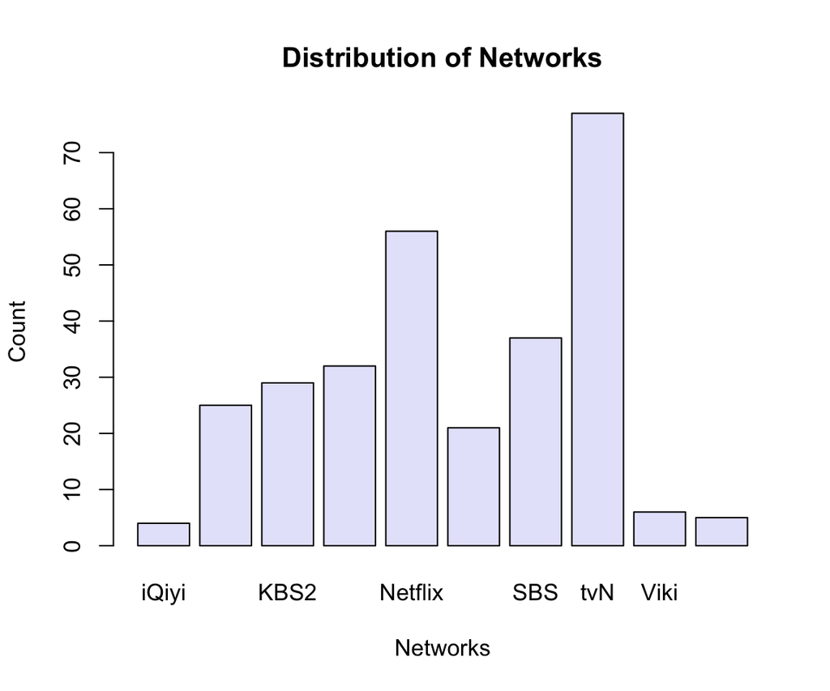

This graph shows the distribution of the original networks for the top 250 kdramas based on rating (only for networks with more than 2 shows on the list). 26.37% of the shows are from tvN, 19.18% from Netflix, and the lowest are 1.37% from iQiyi, 1.71% from ViuTV, and 2.05% from Viki. The graph shows that the network with the most shows on the list is tvN, followed by Netflix, which are both very big companies.

### Duration

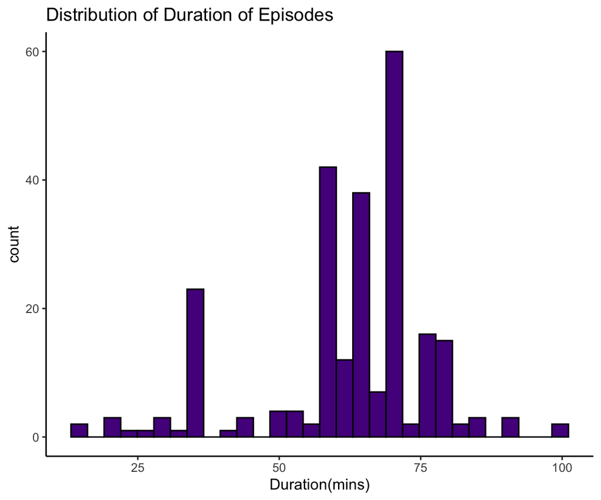

The distribution of the length of episodes for the top 250 kdramas based on ratings has a mean of 62.41. The longest episode is 100 minutes, and the shortest episode is 15 minutes. The graph shows that there are a lot of episodes around one hour and half an hour long.

### Aired

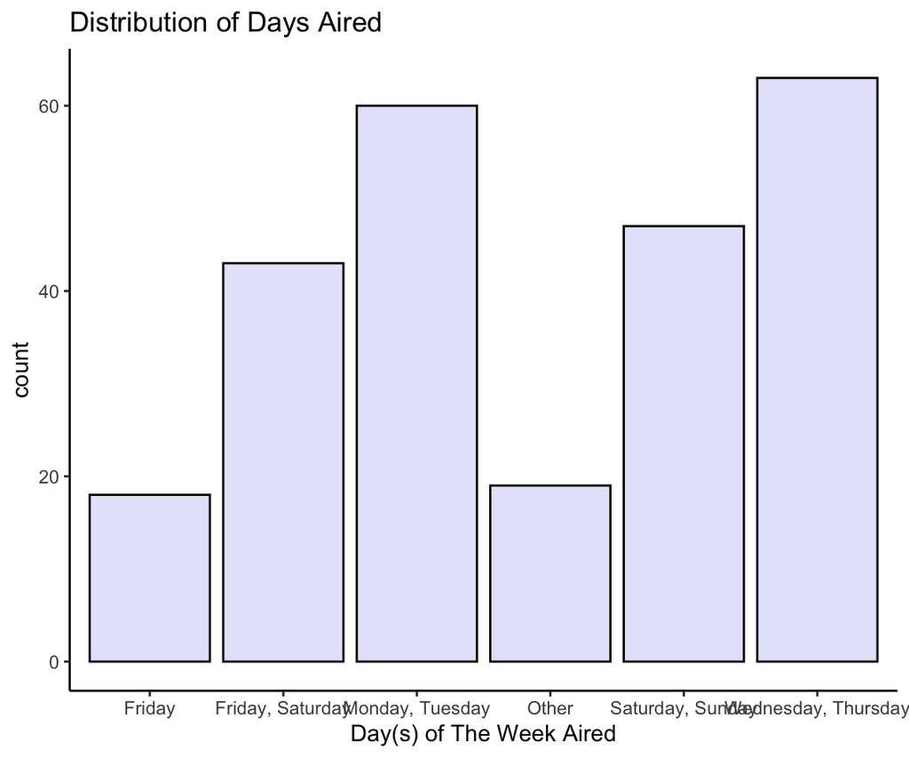

### Number of Episodes

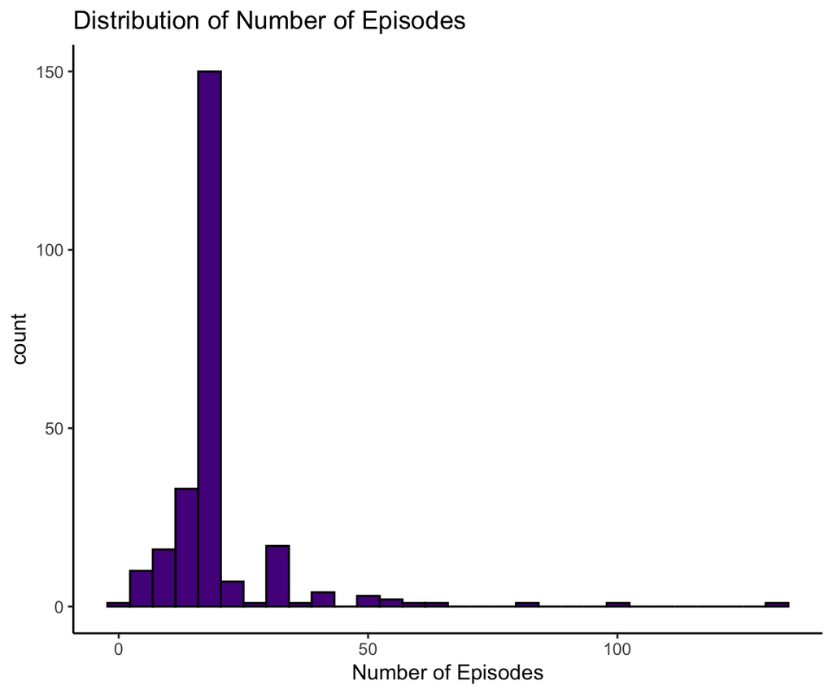

# **Multivariate Analyses**

### Rating and Duration

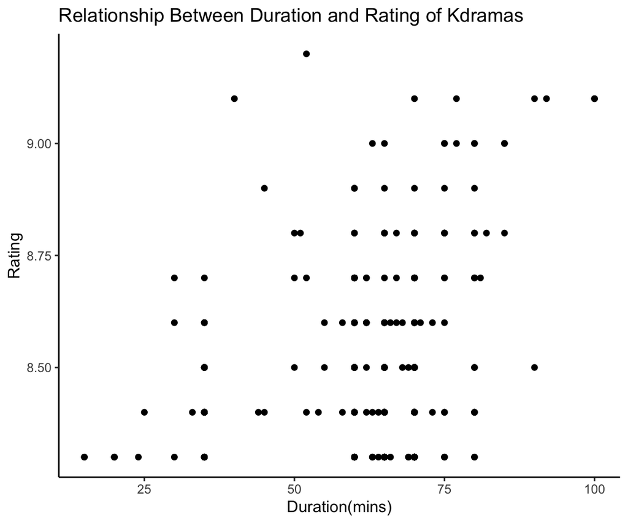

### Duration and Number of Episodes

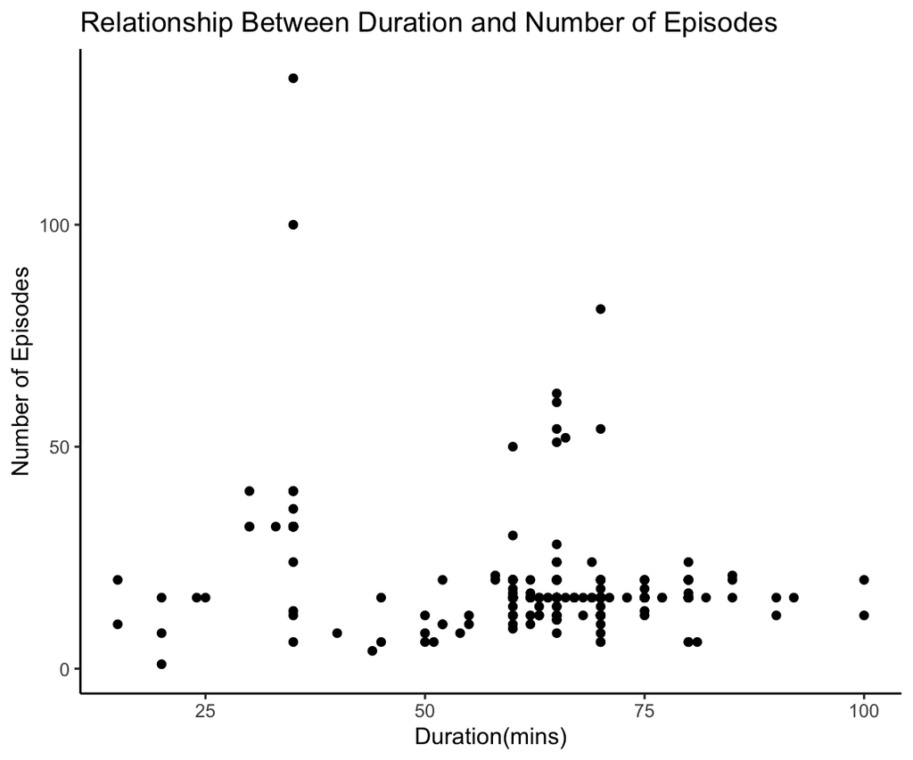

There is a correlation of -0.26 between length of an episode and number of episodes of the top 250 kdramas by rating. The correlation shows that there is a slightly negative relationship between the two variables, but from the graph, it looks like it is because there are a couple of outliers at the top of the graph with 100 episodes. There seems to not be much of a relationship between the two variables.

### Rating and Number of Episodes

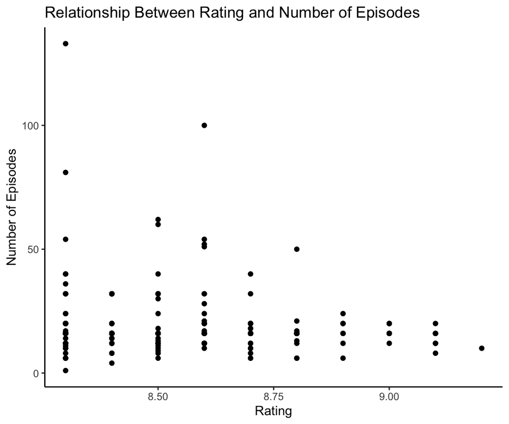

There is a correlation of -0.1 between rating and number of episodes of the top 250 kdramas by rating. The correlation shows that there is a slightly negative relationship between the two variables. This can be seen from the graph, particularly for the shows with a lot of episodes, but the shows with around 50 or less episodes have varied ratings.

### Days Aired and Rating

[figure not shown]

Median Rating by Days Aired

| Days Aired | Median Rating |
| --- | --- |
| Friday | 8.55 |
| Friday, Saturday | 8.50 |
| Monday, Tuesday | 8.50 |
| Other | 8.30 |
| Saturday, Sunday | 8.60 |
| Wednesday, Thursday | 8.40 |

This graph shows the distribution of ratings sorted by the days of the week they aired for the top 250 kdramas by rating. The table shows the median rating by days of the week the show aired. The median rating for each day aired is approximately the same. There is no clear relationship that can be stated. The days with the highest median rating are Saturday and Sunday with 8.6 stars, and the lowest is “Other” at 8.3 stars, which are days that have less than 5 observations in the list of 250 kdramas.

# **Conclusion**

I was not expecting to find any strong relationships between variables because this list doesn’t contain every single kdrama, and there are many external factors that go into deciding characteristics of a show. One finding I did expect was the univariate distribution of networks. The most common turned out to be tvN, which is the biggest network for dramas within South Korea. The next most common one is Netflix, which is very popular globally. The results for one distribution that I was not expecting was day of the week aired. I expected Friday/Saturday or Saturday/Sunday to appear the most on this list because those shows tend to have a higher number of viewers because it is the weekend. However, Monday/Tuesday and Wednesday/Thursday ended up appearing the most. This could also be due to the fact that super popular shows will have more ratings, including low ones, so they will not be on the top 250 list. I did not find any significant relationships among my variables of interest. I think this is because there are so many different factors that impact each other, it is hard to find a relationship between only a couple of variables.

## Choice Elements

1. In-line Code
- I used inline code to display descriptive statistics, such as mean and correlation, with my univariate and multivariate analyses.
2. Create New Variables
- I created a variable for duration in minutes and another one that has the days aired with certain values changed to “other”.
3. Format String Variable
- I reformatted the duration variable. I took out the numbers and calculated the total minutes from each value.
4. Loop
- For the days aired variable, I had to figure out which observations to change to “other” if they did not appear enough. I used a for loop to go through every row in the dataset and determine whether it needed to be changed into “other”.
5. If Statement
- While preparing the data, I used an if statement for both duration and days aired. For duration, I used the if statement to see whether the duration was longer than an hour and needed to be converted or not. For days aired, I checked whether the value in the cell appeared in the table enough times, or if I needed to change it to “other”.

## References

“Top Dramas.” MyDramaList, mydramalist.com/shows/top. Accessed 09 Nov. 2023.  
Hossain, Ahbab. “Top 250 Korean Dramas (KDrama) Dataset.” Kaggle, 21 Jan. 2023, www.kaggle.com/datasets/ahbab911/top-250-korean-dramas-kdrama-dataset.